# Homework 5

STAT 5014

Adeline Guthrie

October 2, 2019

### Problem 2: Sums of Squares

```r
set.seed(12345)
y <- seq(from = 1, to = 100, length.out = 1e8) + rnorm(1e8)

Ybar <- mean(y)
```

1. Sums of Squares calculation using a for loop

```r
system.time({
  SST <- 0

  for (i in 1:1e8) {
    SST <- SST + ((y[i] - Ybar) ^ 2)
  }

})
```

```
##    user  system elapsed
##    8.27    0.00    8.27
```

This is the time breakdown I got from my most recent run:

user system elapsed 12.48 0.07 13.14

2. Sums of Squares calculation using vector operations

```r
system.time({
  Ybar_vect <- rep(Ybar, 1e8)

  diffs <- y - Ybar_vect

  squares <- diffs * diffs

  SST2 <- sum(squares)
})
```

```
##    user  system elapsed
##    0.92    0.47    1.39
```

This is the time breakdown I got from my most recent run:

user system elapsed 1.03 5.34 9.60

I did not include the sampling of y in the time calculation as it is the same for both methods and did not need to be included in the comparision.

### Problem 3: Using the dual nature to our advantage

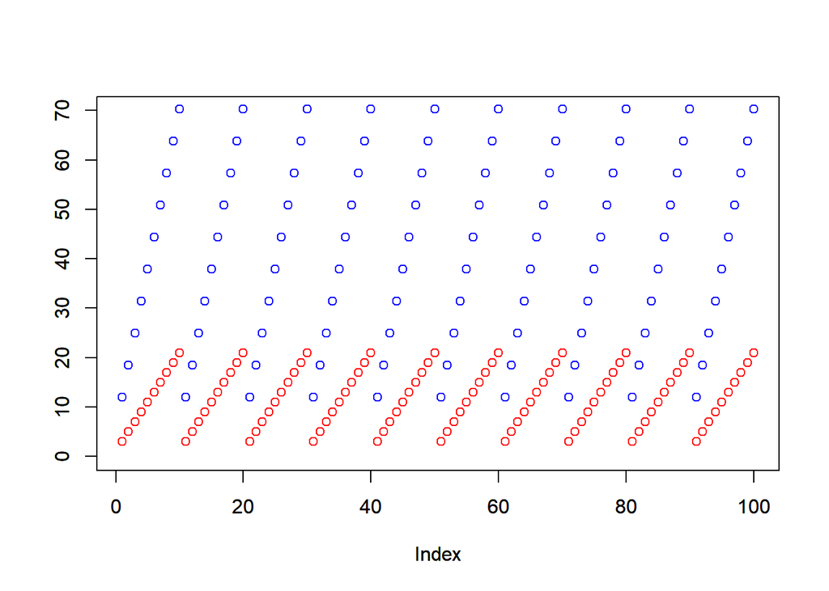

```r
set.seed(1256)

theta <- as.matrix(c(1, 2), nrow = 2)
X <- cbind(1, rep(1:10, 10))
h <- X %*% theta + rnorm(100, 0, 0.2)

alpha <- .005
m <- 100
tol <- 1e-6

h_0 <- function(theta, x) {
  return(theta[1] + (theta[2] * x))
}

# Function to calculate new theta_0
theta_0 <- function(theta, x) {
  total <- 0

  for (i in 1:100) {
    total <- total + (h_0(theta, x[i]) - h[i])
  }
  return(theta[1] - (alpha / m) * total)
}

# Function to calculate new theta_1
theta_1 <- function(theta, x) {
  total <- 0

  for (i in 1:100) {
    total <- total + ((h_0(theta, x[i]) - h[i]) * x[i])
  }
  return(theta[2] - (alpha / m) * total)
}

theta_old <- numeric(2)

while ((abs(theta[1] - theta_old[1]) > tol) && (abs(theta[2] - theta_old[2]) > tol)) {
  theta_old[1] <- theta[1]
  theta_old[2] <- theta[2]

  theta[1] <- theta_0(theta, X)
  theta[2] <- theta_1(theta, X)
}

line <- function(x) {
  return(theta[1] + (theta[2] * x))
}

gradfit <- sapply(X[, 2], line)

lmfit <- lm(h ~ 0 + X)

plot(gradfit, ylim = c(0, 70), ylab = "", col = "Blue")
par(new=T)
plot(lmfit$fitted.values,ylim = c(0, 70), ylab = "", col = "Red")
```

My gradient descent function must be incorrect as the points do not compare well to the lmfit.

Tolerance = 1e-6 Step size = .005

### Problem 4: Inverting matrices

```r
beta_hat <- function(X, y) {
  return(solve(t(X) %*% X) %*% t(X) * y)
}
```

Since we typically know the result of the matrix $({X}^\prime X)^{-1}$, we could replace it with the already computed matrix. ie: replace it with

$$({X}^\prime X)^{-1}=
\left[ {\begin{array}{cc}
\frac{1}{n} + \frac{\bar{X^2}}{S_{xx}} & \frac{-\bar{X}}{S_{xx}} \\
\frac{-\bar{X}}{S_{xx}} & \frac{1}{S_{xx}} \\
\end{array} } \right]$$

to avoid the inverse calculation using solve().

### Problem 5: Need for speed challenge

```r
set.seed(123456)

G <- matrix(sample(c(0, 0.5, 1), size = 16000, replace = T), ncol = 10)
R <- cor(G)  # R: 10 * 10 correlation matrix of G
C <- kronecker(R, diag(1600))  # C is a 16000 * 16000 block diagonal matrix
id <- sample(1:16000, size = 932, replace = F)
q <- sample(c(0, 0.5, 1), size = 15068, replace = T)  # vector of length 15068
A <- C[id, -id]  # matrix of dimension 932 * 15068
B <- C[-id, -id]  # matrix of dimesnion 15068 * 15068
p <- runif(932, 0, 1)
r <- runif(15068, 0, 1)
C <- NULL  # save some memory space
```

1. Matrix A is 112347224 bytes large. Matrix B is 1816357208 bytes large.

```r
# system.time({
#   y <- p + ((A %*% solve(B)) %*% (q - r))
# })
```

These were the time breakdowns I got from my last two runs:

user system elapsed 1432.95 28.78 1729.18

user system elapsed 1249.68 33.01 1390.75

I had to comment the above section out because my computer could not allocate a vector large enough for it to run when knitting to HTML.

After removing B, this is the time breakdown I got from my most recent run:

user system elapsed 0.03 0.17 0.55

```r
system.time({
  G <- NULL
  B <- NULL
  R <- NULL
  id <- NULL
  y <- p + (A %*% (q - r))
})
```

```
##    user  system elapsed
##    0.03    0.06    1.72
```

After clearing the other large matrices that were no longer needed for the calculation, These were the time breakdowns I got from my last two runs:

user system elapsed 0.06 0.00 0.06

user system elapsed 0.05 0.00 0.12